# Bayesian Estimation for Clinical Trial (新药临床试验的贝叶斯估计)

Antigravity

2026-06-13

# Scenario: Phase I Clinical Trial (场景：新药一期临床试验)

- **Prior Belief (先验信息)**: Similar historical drugs have a side-effect rate between **5% and 15%**. We can model this with a **Beta(10, 90)** distribution. Its mean is $10 / (10 + 90) = 10\%$, and most of its probability lies between 5% and 15%.
- **Observed Data (观测数据)**: **20 volunteers** are recruited. **3 people** show side effects, and **17 people** do not.
- **Goal (目标)**: Estimate the true side-effect rate ($\theta$) of this new drug using MCMC and HMC.

# Mathematical Setup (数学建模)

- **Parameter ($\theta$)**: True side-effect rate, constrained between 0 and 1 ($0 \le \theta \le 1$).
- **Prior ($P(\theta)$)**: $\theta \sim \text{Beta}(10, 90)$.
- **Likelihood ($P(\text{Data} \mid \theta)$)**: $y \sim \text{Binomial}(N, \theta)$, where $N = 20$ and $y = 3$.
- **Posterior ($P(\theta \mid \text{Data})$)**: $P(\theta \mid \text{Data}) \propto \text{Prior}(\theta) \times \text{Likelihood}(\theta)$.

### Detailed Explanation of the Beta(10, 90) Prior (深入阐述：为何使用 Beta(10, 90) 作为先验分布)

Why can we use **Beta(10, 90)** to model the prior information that “similar historical drugs have a side-effect rate between 5% and 15%”?

1. **Strict Bounds on [0, 1] (区间限制在 [0, 1])**: A side-effect rate ($\theta$) must be between 0% and 100%. While a Normal distribution could theoretically suggest impossible rates like $-5\%$ or $110\%$, the Beta distribution is mathematically restricted to the range $[0, 1]$, making it perfect for modeling probabilities or proportions. 副作用发生率（概率 $\theta$）必须在 $0 \sim 1$ 之间。正态分布在理论上会延伸到负数或大于 1 的范围，而 Beta 分布的定义域被严格限制在 $[0, 1]$，完美契合概率的物理意义。
2. **Intuitive Pseudo-Counts (直观的“虚拟样本”理解)**: The parameters $\alpha$ (Alpha) and $\beta$ (Beta) can be interpreted as virtual historical counts:
   - $\alpha$: number of virtual “successes” (people with side effects).
   - $\beta$: number of virtual “failures” (people without side effects).
   - $\alpha + \beta$: total number of virtual patients observed.

   For **Beta(10, 90)**:
   - $\alpha = 10$, $\beta = 90$, total virtual patients = 100.
   - This is equivalent to having observed 100 patients in the past, where 10 had side effects.
   - The expected rate is $10 / (10 + 90) = 10\%$.

   我们可以把 $\alpha$ 和 $\beta$ 理解为虚拟的“历史病例数”。对于 `Beta(10, 90)`，相当于我们在做新试验之前，脑袋里已经看过了 100 个历史病例，其中 10 人有副作用，90 人没有，历史平均发生率为 10%。
3. **Probability Mass Alignment (概率密度的契合)**: How well does it match the “5% to 15%” range? We can calculate this in R:
   - Probability that $\theta < 5\%$: `pbeta(0.05, 10, 90)` $\approx 3.4\%$
   - Probability that $\theta < 15\%$: `pbeta(0.15, 10, 90)` $\approx 95.3\%$
   - Probability that $5\% \le \theta \le 15\%$: `pbeta(0.15, 10, 90) - pbeta(0.05, 10, 90)` $\approx \mathbf{91.9\%}$.

   This shows that `Beta(10, 90)` represents a belief where we are ~92% confident that the rate lies between 5% and 15%. 我们有约 92% 的把握确定真实的副作用率落在 5% 到 15% 之间。这非常贴切地模拟了“副作用大约在 5% 到 15% 之间”这句经验论断。
4. **Conjugacy (数学上的共轭先验便利性)**: The Beta distribution is the **conjugate prior** for the Binomial likelihood. This means we can compute the posterior analytically by just adding the new counts:
   $$\text{Posterior} = \text{Beta}(\alpha + \text{observed side effects}, \beta + \text{observed healthy}) = \text{Beta}(10 + 3, 90 + 17) = \text{Beta}(13, 107)$$
   The true mean of this posterior is $13 / (13 + 107) \approx 10.83\%$. Beta 分布是二项分布的共轭先验。这使得计算后验分布变得极其简单，只需把实际观测到的数据人数直接加上去即可得到 `Beta(13, 107)`，均值约为 10.83%。

#### Detailed Explanation of Conjugacy (共轭先验的详细数学原理与推导)

##### What is a Conjugate Prior? (什么是共轭先验？)

In Bayesian inference, the posterior distribution is computed as:
$$\text{Posterior} \propto \text{Prior} \times \text{Likelihood}$$
Generally, multiplying two completely different probability density functions (PDFs) results in a messy, complex formula. Finding the properties of this posterior (such as its mean or variance) would require solving complex calculus integrals, which can be extremely difficult.

However, if the **Prior** and the **Posterior** belong to the **same probability distribution family** (e.g., they are both Beta distributions), we call the Prior a **Conjugate Prior (共轭先验)** for that Likelihood. 在贝叶斯推断中，如果**先验分布**与通过观测数据计算出的**后验分布**属于**同一种概率分布族**（例如先验和后验都是 Beta 分布），我们称这个先验分布为该似然函数的**共轭先验**。它的最大好处是避免了复杂的微积分计算。

##### The Simple Algebra of Beta-Binomial Conjugacy (Beta-Binomial 共轭的数学推导)

Let’s see how the math simplifies when we multiply Beta (Prior) and Binomial (Likelihood):

1. **Beta Prior PDF (Beta 先验概率密度)**: For $\theta \sim \text{Beta}(\alpha, \beta)$, ignoring constant normalizing terms:
   $$P(\theta) \propto \theta^{\alpha - 1} (1 - \theta)^{\beta - 1}$$
2. **Binomial Likelihood PMF (二项分布似然度)**: For observing $y$ side effects out of $N$ trials, ignoring the combination constant $\binom{N}{y}$:
   $$P(\text{Data} \mid \theta) \propto \theta^y (1 - \theta)^{N - y}$$
3. **Multiplying Them Together (两式相乘计算后验)**:
   $$P(\theta \mid \text{Data}) \propto P(\theta) \times P(\text{Data} \mid \theta)$$
   $$P(\theta \mid \text{Data}) \propto \left[ \theta^{\alpha - 1} (1 - \theta)^{\beta - 1} \right] \times \left[ \theta^y (1 - \theta)^{N - y} \right]$$
4. **Combine Exponents (指数合并)**: Grouping the terms of $\theta$ and $(1 - \theta)$ together:
   $$P(\theta \mid \text{Data}) \propto \theta^{(\alpha + y) - 1} (1 - \theta)^{(\beta + N - y) - 1}$$

##### The Magic Result (魔法般的结果)

Look at the final formula. It has the exact same mathematical form as our initial Beta prior PDF, but with updated parameters: * New $\alpha' = \alpha + y$ (Old successes + observed successes) * New $\beta' = \beta + N - y$ (Old healthy + observed healthy)

Therefore, the posterior distribution is exactly:
$$\theta \mid \text{Data} \sim \text{Beta}(\alpha + y, \; \beta + N - y)$$
No integration or MCMC is mathematically needed to find the peak or bounds of this posterior; we simply add the numbers. 我们只需要做简单的加法（历史成功+现实成功，历史失败+现实失败），就能瞬间得到后验分布 `Beta(13, 107)`。

##### Why do we still use MCMC/HMC? (既然有共轭，为什么还要用 MCMC/HMC？)

Conjugacy only works for simple, single-parameter models (like Beta-Binomial, Normal-Normal). In real-world data science, we deal with multi-level hierarchical models or non-linear structures. For those models, no conjugate priors exist, and the multiplication results in highly complex mathematical functions. In these cases, we **must** rely on numerical simulation algorithms like MCMC or HMC to explore the parameter space. 虽然共轭先验极度优雅，但它只适用于非常简单的单参数模型。在现实研究中，遇到复杂的非线性、多层级贝叶斯模型时，后验分布的形式会极其混乱，根本找不到对应的共轭关系。这时候，我们就必须依赖 MCMC 和 HMC 这类模拟方法来帮我们寻找答案。

### Why 10 and 90? Why not (1, 9) or (100, 900)? (为什么是 10 和 90？为什么不能是 1 和 9，或者 100 和 900？)

Although all three pairs yield a mean of $10\%$, they represent vastly different levels of **Prior Strength (先验强度)** (or confidence in our historical knowledge):

1. **Beta(1, 9) — Too Weak (太弱的先验)**:
   - **Interpretation**: Equivalent to having seen only 10 historical patients (1 side effect, 9 healthy).
   - **95% Interval**: Roughly $[0.2\%, 33.6\%]$.
   - **Problem**: This is far wider than our historical range of “5% to 15%”. It says “we think the rate is 10%, but it could easily be 33%”. It doesn’t represent historical consensus well.
   - `Beta(1, 9)` 相当于只看过 10 个历史病例。其 95% 置信区间宽达 $0.2\% \sim 33.6\%$，这比我们已知的“5%~15%”范围要宽得多，说明信息量太少，先验太微弱。
2. **Beta(100, 900) — Too Strong (太强的先验)**:
   - **Interpretation**: Equivalent to having seen 1000 historical patients (100 side effects, 900 healthy).
   - **95% Interval**: Roughly $[8.2\%, 11.9\%]$.
   - **Problem**: This is far narrower than “5% to 15%”. It represents absolute certainty. If we run a new trial of 20 people and observe 3 side effects (15%), this strong prior will completely dominate and ignore the new data. The posterior would be $\text{Beta}(100+3, 900+17) = \text{Beta}(103, 917)$, with a mean of $10.1\%$, virtually unchanged.
   - `Beta(100, 900)` 相当于看过 1000 个历史病例。其 95% 置信区间非常窄（$8.2\% \sim 11.9\%$）。如果用它，先验信息会完全统治我们的新数据。即便新试验里有 3/20 人出现副作用，估计值也几乎不会从 10% 发生挪动，新试验相当于白做了。
3. **Beta(10, 90) — Just Right (恰到好处)**:
   - **Interpretation**: Equivalent to 100 historical patients.
   - **95% Interval**: Roughly $[4.9\%, 16.5\%]$.
   - **Solution**: This perfectly matches the historical range of “5% to 15%” (covering ~92% of the probability density). It represents historical knowledge while remaining open enough to be updated by new data (our 20-patient trial successfully shifted the mean to 10.83%).
   - `Beta(10, 90)` 相当于 100 个历史病例，其 95% 置信区间是 $4.9\% \sim 16.5\%$，完美契合了“5%~15%”的历史经验。它既保留了历史信息，又给新试验（20个样本）留下了足够的影响空间。

#### How to calculate this mathematically? (数学上如何推导？)

If we want a Beta distribution with a target mean ($\mu = 0.10$) and standard deviation ($\sigma \approx 0.03$ to fit the 5%-15% range), we can use the **Method of Moments (矩估计法)** formulas:
$$\alpha = \mu \left( \frac{\mu(1-\mu)}{\sigma^2} - 1 \right) = 0.10 \times \left( \frac{0.10 \times 0.90}{0.03^2} - 1 \right) = 0.10 \times (100 - 1) = 9.9 \approx 10$$
$$\beta = (1-\mu) \left( \frac{\mu(1-\mu)}{\sigma^2} - 1 \right) = 0.90 \times \left( \frac{0.10 \times 0.90}{0.03^2} - 1 \right) = 0.90 \times (100 - 1) = 89.1 \approx 90$$
This is exactly how the values 10 and 90 are mathematically derived!

# 1. MCMC from Scratch (手写 MCMC 模拟)

We will write a Metropolis-Hastings sampler to walk along the $\theta$ interval $[0, 1]$.

```r
library(ggplot2)
```

```r
# Define target posterior density function (on log scale)
target_log_posterior <- function(theta) {
  # If theta is outside [0, 1], it is impossible (probability = 0, log probability = -Inf)
  if (theta < 0 || theta > 1) {
    return(-Inf)
  }

  # Log Prior: Beta(10, 90)
  log_prior <- dbeta(theta, shape1 = 10, shape2 = 90, log = TRUE)
  # Log Likelihood: Binomial(20, 3)
  log_likelihood <- dbinom(x = 3, size = 20, prob = theta, log = TRUE)

  return(log_prior + log_likelihood)
}

# Run MCMC
run_clinical_mcmc <- function(iterations, start_theta, sd_proposal) {
  chain <- numeric(iterations)
  chain[1] <- start_theta
  accepted <- 0

  for (t in 2:iterations) {
    current_theta <- chain[t - 1]

    # Propose a new theta using Normal distribution
    proposed_theta <- rnorm(1, mean = current_theta, sd = sd_proposal)

    # Calculate acceptance ratio
    log_alpha <- target_log_posterior(proposed_theta) - target_log_posterior(current_theta)
    alpha <- exp(log_alpha)

    if (runif(1) < alpha) {
      chain[t] <- proposed_theta
      accepted <- accepted + 1
    } else {
      chain[t] <- current_theta
    }
  }
  return(list(chain = chain, rate = accepted / (iterations - 1)))
}
```

### Line-by-Line Code Walkthrough (代码逐行详细解读)

Let’s break down the MCMC code line-by-line:

#### 1. The Target Posterior Density Function (计算后验概率密度)

- `target_log_posterior <- function(theta) { ... }`
  - **English**: Defines a function that calculates the height (log probability density) of our target island at any given side-effect rate `theta`.
  - **Chinese**: 定义目标分布的“高度计”。输入任意的副作用率 `theta`，它就会输出该位置对应的对数后验概率密度。
- `if (theta < 0 || theta > 1) { return(-Inf) }`
  - **English**: Ensures `theta` stays between 0 and 1. If it walks off the island ($<0$ or $>1$), it returns negative infinity ($-\infty$, representing 0 probability) to force the MCMC explorer back.
  - **Chinese**: 保证 `theta` 处于合法的 $[0, 1]$ 区间。一旦越界，立即返回负无穷大（即概率为 0），强制阻止探索者越界。
- `log_prior <- dbeta(theta, shape1 = 10, shape2 = 90, log = TRUE)`
  - **English**: Calculates the log density of the prior distribution $\text{Beta}(10, 90)$ at `theta`.
  - **Chinese**: 计算先验分布 $\text{Beta}(10, 90)$ 在当前 `theta` 处的对数概率密度。
- `log_likelihood <- dbinom(x = 3, size = 20, prob = theta, log = TRUE)`
  - **English**: Calculates the log likelihood of observing 3 side-effects out of 20 trials if the true rate is `theta`.
  - **Chinese**: 计算在副作用率为 `theta` 的假设下，20 人中刚好出现 3 人副作用的对数概率（似然值）。
  - **Why use `log = TRUE`? (为什么使用 `log = TRUE`？)**:
    - **1. Prevent Underflow (防止数值下溢)**: Computers struggle with tiny probabilities (e.g., $10^{-500}$), rounding them to absolute $0$, which causes division-by-zero errors and crashes the MCMC sampler. Taking the log translates tiny probabilities into stable negative numbers (e.g., $-1151$), preventing numerical collapse. 计算机在处理极小概率（如 $10^{-500}$）时会直接归零，导致 $0/0$ 错误使 MCMC 崩溃。使用对数后，极小概率变成正常的负数（如 $-1151$），避免了数值下溢。
    - **2. Speed (化乘为加)**: Multiplying thousands of float probabilities is slow and numerically unstable. Taking the log lets us use addition instead of multiplication: $\log(A \times B) = \log(A) + \log(B)$, which is much faster for CPUs. 在贝叶斯计算中，总概率需要对所有样本的概率求乘积。使用对数后，乘法转变为加法（$\log(A \times B) = \log(A) + \log(B)$），大幅提高 CPU 的计算速度且数值更加稳定。
    - **3. HMC Gradients (为 HMC 提供平滑坡度)**: Direct probabilities create steep cliffs, while log-probabilities stretch them into smooth curves, enabling HMC (Hamiltonian Monte Carlo) to calculate stable gradients (slopes) for the sliding puck. 对于 HMC 算法，直接对原始概率求导极不稳定。对数概率曲线则非常平缓，能够为 HMC 算法中的小球运动提供稳定的梯度（重力坡度）。
- `return(log_prior + log_likelihood)`
  - **English**: Combines prior and likelihood. Because we are in log scale, we add them instead of multiplying: $\log(\text{Posterior}) = \log(\text{Prior}) + \log(\text{Likelihood})$.
  - **Chinese**: 将先验与似然相加得到后验高度。由于在对数尺度下，乘法变加法。

#### 2. The MCMC Loop Engine (MCMC 循环控制引擎)

- `run_clinical_mcmc <- function(iterations, start_theta, sd_proposal) { ... }`
  - **English**: The main sampler function taking total steps, starting value, and proposal step size (standard deviation) as arguments.
  - **Chinese**: MCMC 采样函数，接受迭代步数、起点值、和步长标准差。
- `chain <- numeric(iterations)`
  - **English**: Pre-allocates a vector of zeros to store the coordinates (samples) of each step.
  - **Chinese**: 在内存中预先分配一块全 0 数组，作为记录探索者每一步站立坐标的“账本”。
- `chain[1] <- start_theta`
  - **English**: Saves the starting point as the first sample in the chain.
  - **Chinese**: 将指定的起点坐标写入账本的第一行。
- `for (t in 2:iterations) { ... }`
  - **English**: A loop that takes one step at a time from step 2 to the end.
  - **Chinese**: 核心循环控制，从第 2 步一直走到最后一步。
- `current_theta <- chain[t - 1]`
  - **English**: Gets the position of the explorer in the previous step.
  - **Chinese**: 获取探索者当前（上一时刻）所在的副作用率位置。
- `proposed_theta <- rnorm(1, mean = current_theta, sd = sd_proposal)`
  - **English**: Proposes a new candidate value by drawing a random number from a normal distribution centered at the current position.
  - **Chinese**: 投石问路：以当前位置为中心，利用正态分布随机抽取一个值作为“候选新位置”。
- `log_alpha <- target_log_posterior(proposed_theta) - target_log_posterior(current_theta)`
  - **English**: Computes the difference in log heights between the proposed and current positions.
  - **Chinese**: 计算新旧位置的对数高度差。
- `alpha <- exp(log_alpha)`
  - **English**: Converts the log difference back to a probability ratio: $\alpha = P(\text{new}) / P(\text{old})$.
  - **Chinese**: 通过指数函数将对数高度差还原为正常的概率比值 $\alpha$。
- `if (runif(1) < alpha) { ... } else { ... }`
  - **English**: The Metropolis-Hastings acceptance step. If the new spot is higher ($\alpha \ge 1$), we always accept. If it is lower ($\alpha < 1$), we accept it with probability $\alpha$ by comparing it to a random number between 0 and 1 (`runif(1)`).
  - **English/Chinese (Bilingual)**: 梅特罗波利斯-海斯廷斯接受决策。如果新位置更高，必定接受；如果新位置变矮了，则以概率 $\alpha$ 接受（即掷随机数 `runif(1)` 小于 $\alpha$ 时接受，否则保持原地不动）。
- `return(list(chain = chain, rate = accepted / (iterations - 1)))`
  - **English**: Outputs the full chain of samples and the acceptance rate.
  - **Chinese**: 输出全部的坐标账本以及总接受率。

# 2. Run MCMC and Plot Traceplot (运行并绘制轨迹图)

Let’s start our explorer at a bad guess: **$\theta = 0.50$ (50% side-effect rate)**.

```r
iterations <- 3000

# Case 1: Too Small Stride (步长太小)
mcmc_small <- run_clinical_mcmc(iterations, start_theta = 0.50, sd_proposal = 0.001)

# Case 2: Just Right (合适步长)
mcmc_good  <- run_clinical_mcmc(iterations, start_theta = 0.50, sd_proposal = 0.03)

# Case 3: Too Large Stride (步长太大)
mcmc_large <- run_clinical_mcmc(iterations, start_theta = 0.50, sd_proposal = 0.40)

# Reference for subsequent calculations (以合适步长的结果进行后验分析)
mcmc_res <- mcmc_good
```

### Traceplot Comparison (轨迹图对比)

Let’s plot the traceplots of the three scenarios side-by-side to see how the step size affects convergence and mixing.

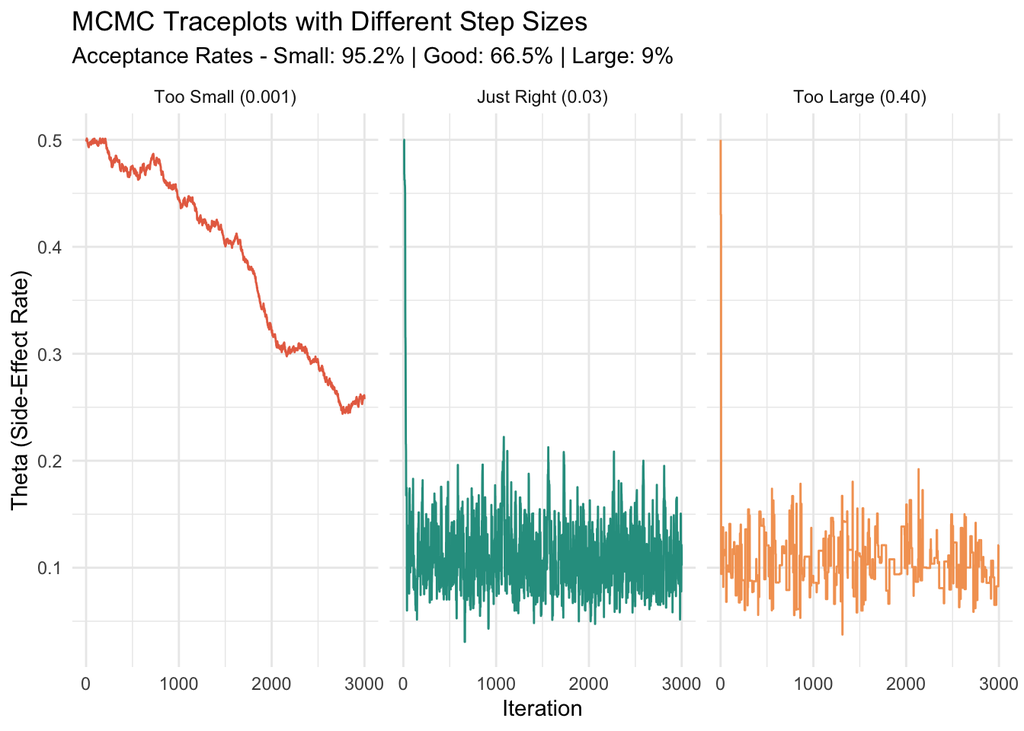

```r
df_small <- data.frame(Iteration = 1:iterations, Theta = mcmc_small$chain, Stride = "Too Small (0.001)")
df_good  <- data.frame(Iteration = 1:iterations, Theta = mcmc_good$chain, Stride = "Just Right (0.03)")
df_large <- data.frame(Iteration = 1:iterations, Theta = mcmc_large$chain, Stride = "Too Large (0.40)")

df_all <- rbind(df_small, df_good, df_large)
df_all$Stride <- factor(df_all$Stride, levels = c("Too Small (0.001)", "Just Right (0.03)", "Too Large (0.40)"))

ggplot(df_all, aes(x = Iteration, y = Theta, color = Stride)) +
  geom_line() +
  facet_wrap(~Stride, ncol = 3) +
  scale_color_manual(values = c("Too Small (0.001)" = "#e76f51", "Just Right (0.03)" = "#2a9d8f", "Too Large (0.40)" = "#f4a261")) +
  labs(
    title = "MCMC Traceplots with Different Step Sizes",
    subtitle = paste0("Acceptance Rates - Small: ", round(mcmc_small$rate * 100, 1),
                      "% | Good: ", round(mcmc_good$rate * 100, 1),
                      "% | Large: ", round(mcmc_large$rate * 100, 1), "%"),
    x = "Iteration",
    y = "Theta (Side-Effect Rate)"
  ) +
  theme_minimal() +
  theme(legend.position = "none")
```

### Posterior Distribution (后验分布图)

If we discard the first 500 iterations (burn-in) and plot the histogram of the remaining steps, we get the probability distribution of the true side-effect rate.

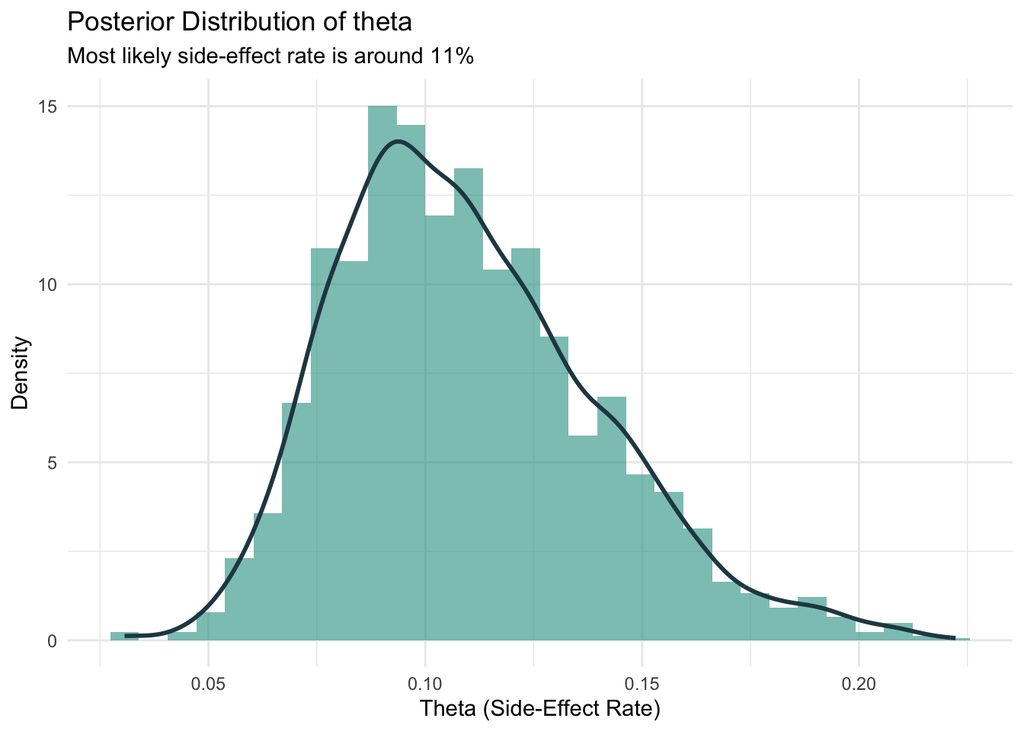

```r
# Discard the first 500 steps (burn-in)
post_samples <- df_good$Theta[501:iterations]

df_post <- data.frame(Theta = post_samples)

ggplot(df_post, aes(x = Theta)) +
  geom_histogram(aes(y = after_stat(density)), bins = 30, fill = "#2a9d8f", alpha = 0.6) +
  geom_density(color = "#264653", linewidth = 1) +
  labs(
    title = "Posterior Distribution of theta",
    subtitle = "Most likely side-effect rate is around 11%",
    x = "Theta (Side-Effect Rate)",
    y = "Density"
  ) +
  theme_minimal()
```

```r
# Summary statistics
mean_theta <- mean(post_samples)
quantile_theta <- quantile(post_samples, probs = c(0.025, 0.975))
```

- **Result (估计结果)**: The estimated average side-effect rate is **10.97%**.
- **95% Credible Interval (95% 置信区间)**: We are 95% confident that the true side-effect rate is between **6.08%** and **17.84%**.

# 3. Using `rstan` (使用 `rstan` 拟合)

Let’s do the exact same analysis using `rstan`.

```r
library(rstan)

stan_code <- "
data {
  int<lower=0> N;
  int<lower=0> y;
}
parameters {
  real<lower=0, upper=1> theta;
}
model {
  theta ~ beta(10, 90);  // Prior
  y ~ binomial(N, theta); // Likelihood
}
"

fit <- stan(
  model_code = stan_code,
  data = list(N = 20, y = 3),
  iter = 2000,
  chains = 4
)
```

```r
# Print estimation results
print(fit)
```

```
## Inference for Stan model: anon_model.
## 4 chains, each with iter=2000; warmup=1000; thin=1;
## post-warmup draws per chain=1000, total post-warmup draws=4000.
##
##         mean se_mean   sd   2.5%    25%    50%    75%  97.5% n_eff Rhat
## theta   0.11    0.00 0.03   0.06   0.09   0.11   0.12   0.17  1138    1
## lp__  -41.63    0.02 0.67 -43.53 -41.77 -41.37 -41.21 -41.16  1339    1
##
## Samples were drawn using NUTS(diag_e) at Sat Jun 13 01:10:24 2026.
## For each parameter, n_eff is a crude measure of effective sample size,
## and Rhat is the potential scale reduction factor on split chains (at
## convergence, Rhat=1).
```

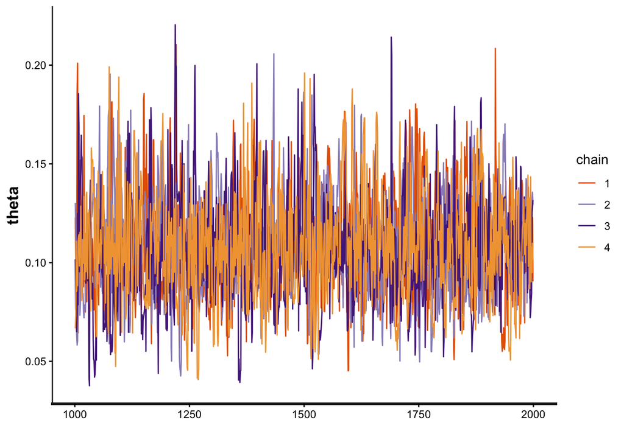

```r
# Traceplot of the 4 chains
stan_trace(fit, pars = "theta")
```

### How does Stan (HMC) solve the Step Size problem automatically? (Stan 与 HMC 是如何自动解决步长选择问题的？)

When using `rstan` to fit the clinical trial model, we did not specify any `sd_proposal` or step size. Yet, Stan runs extremely efficiently. This is due to its advanced engineering:

1. **No-U-Turn Sampler (NUTS, 无U转弯采样器)**: Instead of taking random steps, Stan simulates a physics hockey puck sliding in a gravity bowl (HMC). By default, it uses NUTS, which automatically determines **how long the puck should slide** before recording a sample. It stops the simulation the split second the puck begins to loop back on itself (making a U-turn), preventing wasteful backtracking. NUTS 算法类似于一个“智能冰球”。它会自动决定每一回合冰球应该滑行多久。一旦算法监测到冰球开始“调头往回走”（U-Turn），就会立刻踩刹车并记录样本，从而避免了做无用功。
2. **Warmup Adaptation of Step Size ($\epsilon$) (预热期自动步长优化)**: In HMC, the step size of the physical simulator is called **$\epsilon$ (Epsilon)**. During the **Warmup phase** (the first 1000 iterations), Stan runs a mathematical adaptation algorithm called **Dual Averaging (对偶平均算法)**:
   - If the simulated steps are rejected too often, it **decreases** $\epsilon$.
   - If the steps are accepted too easily but are too small, it **increases** $\epsilon$.
   - It targets an optimal acceptance probability (set to **$80\%$** by default for NUTS, which is mathematically the optimal sweet spot for HMC physics). 在预热阶段，Stan 使用“对偶平均”算法自动优化滑行的物理步长 $\epsilon$。如果接受率偏低就调小步长，接受率偏高就调大步长，最终将接受率锁定在数学上最完美的 **$80\%$**。
3. **Mass Matrix Adaptation (质量矩阵自适应)**: In complex models with many parameters, some parameters have wide ranges while others are highly constrained. During warmup, Stan estimates the variance of each parameter and creates a virtual **Mass Matrix (质量矩阵)** to scale the step sizes. Parameters with wider variance get larger steps, and highly sensitive parameters get smaller, safer steps. 在多参数模型中，不同参数的波动性大不相同。Stan 会在预热期估算每个参数的变异度，并生成虚拟的“质量矩阵”来个性化定制每个维度的步长。

Consequently, Stan completely relieves scientists from manually tuning proposal step sizes (`sd_proposal`), ensuring robust convergence out-of-the-box! 这使得我们在使用 Stan 时，彻底不需要手动去调试类似 `sd_proposal` 的步长参数，模型能自动找到最高效的搜索轨道。